# Autoencoders

```python
import torch
import torch.nn as nn
import numpy as np
import matplotlib.pyplot as plt

from sklearn.datasets import make_moons
```

## Linear Autoencoder

We first implement a linear autoencoder  
. The **LinearAE** class construction receives two values:

- **d_in** - the input dimension.
- **d_enc** - the dimension of the encoding.

Each encoder saves two inner members:

- **self.encoder** - an object of type **nn.Linear** implementing the encoding network.
- **self.decoder** - an object of type **nn.Linear** implementing the decoding network.

```python
class LinearAE(nn.Module):

    def __init__(self, d_in, d_enc):
        super().__init__()
        self.encoder = nn.Linear(d_in, d_enc)
        self.decoder = nn.Linear(d_enc, d_in)

    def forward(self, x):
        return self.decoder(self.encoder(x))
```

## Network Autoencoder

Next, we construct a NN-based autoencoder, using the following architecture:

[figure not shown]

All layers are linear, but note the dimensions in each layer, as well as the activation function (ReLU/Tanh).

The **NetworkAE** class construction receives four values:

- **d_in** - the input dimension.
- **d_enc** - the dimension of the encoding.
- **d_1** - the dimension of the first (and third) intermediate level.
- **d_2** - the dimension of the second intermediate level.

Each encoder saves two inner objects:

- **self.encoder** - an object of type **nn.Sequential** implementing the encoding network.
- **self.decoder** - an object of type **nn.Sequential** implementing the decoding network.

```python
class NetworkAE(nn.Module):

    def __init__(self, d_in, d_enc, d1, d2):
        super().__init__()
        self.encoder = nn.Sequential(nn.Linear(d_in, d1),
                                     nn.Tanh(),
                                     nn.Linear(d1, d2),
                                     nn.ReLU(),
                                     nn.Linear(d2, d1),
                                     nn.ReLU(),
                                     nn.Linear(d1, d_enc))
        self.decoder = nn.Sequential(nn.Linear(d_enc, d1),
                                     nn.ReLU(),
                                     nn.Linear(d1, d2),
                                     nn.ReLU(),
                                     nn.Linear(d2, d1),
                                     nn.Tanh(),
                                     nn.Linear(d1, d_in))


    def forward(self, x):
        return self.decoder(self.encoder(x))
```

## Training

Next, you implement a function that performs the training for a given network.

The input parameters are:

- **NN** - the neural network (**nn.Module**) to train.
- **X** - the training data (**torch.Tensor**).  
  The dimensions of **X** are ($n\times d_{\mathrm{in}}$), where $n$ is the size of the training set, and $d_{\mathrm{in}}$ is the dimension of the network input.
- **learning_rate** - rate of gradient descent steps.
- **max_iter** - number of iterations to run.
- **print_iter** - when to print status update.

```python
def train_nn(NN, X, learning_rate, max_iter, print_iter=100):

    optimiser = torch.optim.SGD(NN.parameters(), lr = learning_rate)
    loss_fn = torch.nn.MSELoss(reduction='sum')

    for epoch in range(max_iter):

        X_pred = NN(X)
        loss = loss_fn(X_pred, X)

        if (epoch+1) % print_iter == 0:
            print(f'Epoch: {epoch+1}, Loss: {loss.item()}')

        optimiser.zero_grad()
        loss.backward()
        optimiser.step()

    return NN
```

## Testing the Autoencoders

To test these encoders, we use the two-moon dataset.

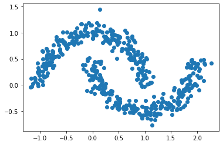

```python
SEED = 210711042
N = 500
SIG = 0.1
X, _ = make_moons(n_samples=N, noise=SIG, random_state=SEED)
plt.scatter(X[:,0],X[:,1])
plt.axis('equal');
```

```python
XT = torch.tensor(X, dtype=torch.float32)
```

Our goal is to find a suitable 1-dimensional representation of this 2-dimensional data.

```python
linenc = LinearAE(2, 1)
linenc = train_nn(linenc, XT, learning_rate=5e-04, max_iter=1000)
```

```
Epoch: 100, Loss: 96.56216430664062
Epoch: 200, Loss: 96.56212615966797
Epoch: 300, Loss: 96.5621337890625
Epoch: 400, Loss: 96.5621337890625
Epoch: 500, Loss: 96.5621337890625
Epoch: 600, Loss: 96.5621337890625
Epoch: 700, Loss: 96.5621337890625
Epoch: 800, Loss: 96.5621337890625
Epoch: 900, Loss: 96.5621337890625
Epoch: 1000, Loss: 96.5621337890625
```

```python
netenc = NetworkAE(d_in=2, d_enc=1, d1=10, d2=25)
netenc = train_nn(netenc, XT, learning_rate=5e-04, max_iter=10000)
```

```
Epoch: 100, Loss: 145.1793975830078
Epoch: 200, Loss: 109.06774139404297
Epoch: 300, Loss: 54.61616516113281
Epoch: 400, Loss: 57.13446807861328
Epoch: 500, Loss: 44.31135559082031
Epoch: 600, Loss: 50.07269287109375
Epoch: 700, Loss: 48.18919372558594
Epoch: 800, Loss: 35.7377815246582
Epoch: 900, Loss: 35.59989547729492
Epoch: 1000, Loss: 38.22804260253906
Epoch: 1100, Loss: 33.766075134277344
Epoch: 1200, Loss: 35.52913284301758
Epoch: 1300, Loss: 31.04424285888672
Epoch: 1400, Loss: 29.961517333984375
Epoch: 1500, Loss: 35.26736831665039
Epoch: 1600, Loss: 28.458171844482422
Epoch: 1700, Loss: 28.232315063476562
Epoch: 1800, Loss: 25.74853515625
Epoch: 1900, Loss: 24.69481086730957
Epoch: 2000, Loss: 23.363853454589844
Epoch: 2100, Loss: 23.7608585357666
Epoch: 2200, Loss: 26.50672149658203
Epoch: 2300, Loss: 21.805360794067383
Epoch: 2400, Loss: 19.22904396057129
Epoch: 2500, Loss: 22.11136245727539
Epoch: 2600, Loss: 17.781848907470703
Epoch: 2700, Loss: 17.536663055419922
Epoch: 2800, Loss: 19.00665283203125
Epoch: 2900, Loss: 15.53482723236084
Epoch: 3000, Loss: 16.21259117126465
Epoch: 3100, Loss: 14.71164321899414
Epoch: 3200, Loss: 14.423664093017578
Epoch: 3300, Loss: 15.690651893615723
Epoch: 3400, Loss: 14.001856803894043
Epoch: 3500, Loss: 14.527196884155273
Epoch: 3600, Loss: 13.062973976135254
Epoch: 3700, Loss: 20.513336181640625
Epoch: 3800, Loss: 12.508989334106445
Epoch: 3900, Loss: 12.707592964172363
Epoch: 4000, Loss: 13.028851509094238
```

[output cut: 45 more lines]

```
Epoch: 8600, Loss: 9.69924545288086
Epoch: 8700, Loss: 14.038476943969727
Epoch: 8800, Loss: 9.188523292541504
Epoch: 8900, Loss: 7.946074485778809
Epoch: 9000, Loss: 9.36130142211914
Epoch: 9100, Loss: 7.463373184204102
Epoch: 9200, Loss: 8.972496032714844
Epoch: 9300, Loss: 8.121110916137695
Epoch: 9400, Loss: 7.438579559326172
Epoch: 9500, Loss: 7.733771324157715
Epoch: 9600, Loss: 9.84853744506836
Epoch: 9700, Loss: 7.881923198699951
Epoch: 9800, Loss: 11.179054260253906
Epoch: 9900, Loss: 7.129364490509033
Epoch: 10000, Loss: 8.220257759094238
```

For a comparison, we also implement a dimension reduction and reconstruction using principal component analysis.

```python
from sklearn.preprocessing import StandardScaler

def pc_transform(X, PCS):
    X = X.T
    scaler = StandardScaler()
    scaler.fit(X.T)
    X = scaler.transform(X.T)
    U, _, _ = np.linalg.svd(X, full_matrices=False)
    result = np.dot((U[:,PCS]).T, X)
    return scaler.inverse_transform(result).T
```

```python
X_PCA = pc_transform(XT.T, [0, 1])
X_LIN = linenc.forward(XT).detach().numpy()
X_NET = netenc.forward(XT).detach().numpy()
```

Below demonstrates the effectiveness of the three methods.

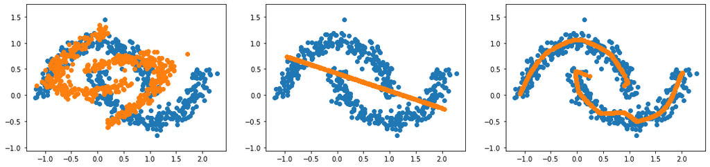

```python
plt.figure(figsize=(18,4))

plt.subplot(1,3,1)
plt.scatter(X[:,0], X[:,1])
plt.scatter(X_PCA[:,0], X_PCA[:,1])
plt.axis('equal');

plt.subplot(1,3,2)
plt.scatter(X[:,0], X[:,1])
plt.scatter(X_LIN[:,0], X_LIN[:,1])
plt.axis('equal');

plt.subplot(1,3,3)
plt.scatter(X[:,0], X[:,1])
plt.scatter(X_NET[:,0], X_NET[:,1])
plt.axis('equal');
```

We test performance of the NN-autencoder on new data from **make_moons**.

```python
SEED = 9987
N = 100
X_new, L_new = make_moons(n_samples=N, noise=SIG, random_state=SEED)
```

```python
X_newT = torch.tensor(X_new, dtype=torch.float32)

XR_new = netenc.forward(X_newT).detach().numpy()
XE_new = netenc.encoder(X_newT).detach().numpy()
```

The below cell shows the 1-dimensional encoded data on the left, and the decoded reconstruction on the right.

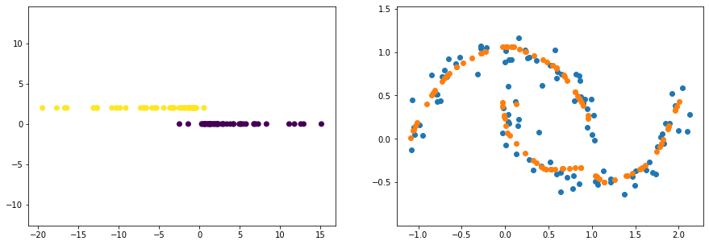

```python
plt.figure(figsize=(15,5))

plt.subplot(1,2,1)
plt.scatter(XE_new,2*L_new, c =L_new)
plt.axis('equal');

plt.subplot(1,2,2)
plt.scatter(X_new[:,0],X_new[:,1])
plt.scatter(XR_new[:,0],XR_new[:,1])
plt.axis('equal');
```

We can see what the decoder is doing by applying it to latent encoded space.

```python
linspace = torch.linspace(-20, 20, 1000)[:, None]
XR_gen = netenc.decoder(linspace).detach().numpy()
```

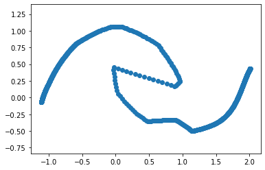

```python
plt.scatter(XR_gen[:,0],XR_gen[:,1])
plt.axis('equal');
```